# Predicting Manner of Exercising from Accelerometer Measurements Using Machine Learning

Lee Kun Min(5 Feb 2017)

## Background

This project aims to predict in which manner participants completed a single exercise, based on recordings provided by accelerometers attached to 4 measurement points on the body. Six male participants aged 20-28 were asked to perform one set of 10 repetitions of the Unilateral Dumbbell Biceps Curl in one correct, and 4 incorrect fashions. Specifically, the exercises were performed:  
* Exactly according to the specification (**Class A**);  
* Throwing elbows to the front (**Class B**);  
* Lifting the dumbbell only halfway (**Class C**);  
* Lowering the dumbbell only halfway (**Class D**); and  
* Throwing the hips to the front (**Class E**).

## Loading in the data and splitting into training and testing sets

The labelled dataset was [downloaded](https://d396qusza40orc.cloudfront.net/predmachlearn/pml-training.csv) on September 22nd, 2015 and loaded into R.

```r
rm(list = ls())
download.file("https://d396qusza40orc.cloudfront.net/predmachlearn/pml-training.csv", "data.csv")
data <- read.csv("data.csv")
```

There were a total of 19622 observations in the labelled dataset, which was large enough to split into training and testing datasets. Sixty percent of the data were assigned to the training set and 40% to the testing set.

```r
require(caret)
set.seed(567)
inTrain <- createDataPartition(y = data$classe, p = 0.6, list = FALSE)
training <- data[inTrain, ]
testing <- data[-inTrain, ]
```

There were a total of 11776 observations in the training set and 7846 in the testing set. The unlabelled validation dataset was also [downloaded](https://d396qusza40orc.cloudfront.net/predmachlearn/pml-testing.csv).

```r
download.file("https://d396qusza40orc.cloudfront.net/predmachlearn/pml-testing.csv", "validation.csv")
validation <- read.csv("validation.csv")
rm(list = c("data", "inTrain"))
```

The validation dataset had 20 observations.

## Data screening and covariate inspection (training set)

The data were initially inspected. A number of variables appeared to have missing variables (e.g., `max_roll_belt`), and also variables that appeared numeric were classed as factor variables (e.g., `kurtosis_roll_belt`. In addition to the 152 predictor variables and the outcome, there also appeared to be a number of variables describing the time in which the exercise was performed and which of the participants performed the exercise.

```r
str(training)
```

```
## 'data.frame':    11776 obs. of  160 variables:
##  $ X                       : int  2 5 7 8 9 10 11 12 13 15 ...
##  $ user_name               : Factor w/ 6 levels "adelmo","carlitos",..: 2 2 2 2 2 2 2 2 2 2 ...
##  $ raw_timestamp_part_1    : int  1323084231 1323084232 1323084232 1323084232 1323084232 1323084232 1323084232 1323084232 1323084232 1323084232 ...
##  $ raw_timestamp_part_2    : int  808298 196328 368296 440390 484323 484434 500302 528316 560359 604281 ...
##  $ cvtd_timestamp          : Factor w/ 20 levels "02/12/2011 13:32",..: 9 9 9 9 9 9 9 9 9 9 ...
##  $ new_window              : Factor w/ 2 levels "no","yes": 1 1 1 1 1 1 1 1 1 1 ...
##  $ num_window              : int  11 12 12 12 12 12 12 12 12 12 ...
##  $ roll_belt               : num  1.41 1.48 1.42 1.42 1.43 1.45 1.45 1.43 1.42 1.45 ...
##  $ pitch_belt              : num  8.07 8.07 8.09 8.13 8.16 8.17 8.18 8.18 8.2 8.2 ...
##  $ yaw_belt                : num  -94.4 -94.4 -94.4 -94.4 -94.4 -94.4 -94.4 -94.4 -94.4 -94.4 ...
##  $ total_accel_belt        : int  3 3 3 3 3 3 3 3 3 3 ...
##  $ kurtosis_roll_belt      : Factor w/ 397 levels "","-0.016850",..: 1 1 1 1 1 1 1 1 1 1 ...
##  $ kurtosis_picth_belt     : Factor w/ 317 levels "","-0.021887",..: 1 1 1 1 1 1 1 1 1 1 ...
##  $ kurtosis_yaw_belt       : Factor w/ 2 levels "","#DIV/0!": 1 1 1 1 1 1 1 1 1 1 ...
```

[output cut: 86 more lines]

### Outcome variable

The outcome variable was fairly evenly distributed between the 5 categories, with the smallest class (Class D) containing 1930 observations (16%), and the largest class (Class A) containing 3348 observations (28%).

```r
table(training$classe)
```

```
##
##    A    B    C    D    E
## 3348 2279 2054 1930 2165
```

```r
prop.table(table(training$classe))
```

```
##
##         A         B         C         D         E
## 0.2843071 0.1935292 0.1744226 0.1638927 0.1838485
```

### Cleaning factor variables

The predictors were cleaned so that those that were incorrectly classified as factor were converted to numeric.

```r
require(magrittr)

asNumeric <- function(x) as.numeric(as.character(x))
factorsNumeric <- function(d) modifyList(d, lapply(d[, sapply(d, is.factor)],
                                                asNumeric))
training %>%
    subset(select = -c(X, user_name, raw_timestamp_part_1, raw_timestamp_part_2,
                      cvtd_timestamp, new_window, num_window, classe)) %>%
    factorsNumeric -> training[ , 8:159]
```

### Screening for missing variables

The variables were then inspected for missingness.

```r
propmiss <- function(dataframe) {
    sapply(dataframe,function(x)
    data.frame(nmiss=sum(is.na(x)),
               n=length(x),
               propmiss=sum(is.na(x))/length(x)))
}

propmiss(training)
```

```
##          X     user_name raw_timestamp_part_1 raw_timestamp_part_2
## nmiss    0     0         0                    0
## n        11776 11776     11776                11776
## propmiss 0     0         0                    0
##          cvtd_timestamp new_window num_window roll_belt pitch_belt
## nmiss    0              0          0          0         0
## n        11776          11776      11776      11776     11776
## propmiss 0              0          0          0         0
##          yaw_belt total_accel_belt kurtosis_roll_belt kurtosis_picth_belt
## nmiss    0        0                11541              11554
## n        11776    11776            11776              11776
## propmiss 0        0                0.9800442          0.9811481
##          kurtosis_yaw_belt skewness_roll_belt skewness_roll_belt.1
## nmiss    11776             11540              11554
## n        11776             11776              11776
## propmiss 1                 0.9799592          0.9811481
##          skewness_yaw_belt max_roll_belt max_picth_belt max_yaw_belt
## nmiss    11776             11535         11535          11541
## n        11776             11776         11776          11776
## propmiss 1                 0.9795346     0.9795346      0.9800442
##          min_roll_belt min_pitch_belt min_yaw_belt amplitude_roll_belt
## nmiss    11535         11535          11541        11535
## n        11776         11776          11776        11776
## propmiss 0.9795346     0.9795346      0.9800442    0.9795346
##          amplitude_pitch_belt amplitude_yaw_belt var_total_accel_belt
## nmiss    11535                11541              11535
## n        11776                11776              11776
## propmiss 0.9795346            0.9800442          0.9795346
##          avg_roll_belt stddev_roll_belt var_roll_belt avg_pitch_belt
## nmiss    11535         11535            11535         11535
## n        11776         11776            11776         11776
## propmiss 0.9795346     0.9795346        0.9795346     0.9795346
##          stddev_pitch_belt var_pitch_belt avg_yaw_belt stddev_yaw_belt
## nmiss    11535             11535          11535        11535
## n        11776             11776          11776        11776
## propmiss 0.9795346         0.9795346      0.9795346    0.9795346
##          var_yaw_belt gyros_belt_x gyros_belt_y gyros_belt_z accel_belt_x
## nmiss    11535        0            0            0            0
## n        11776        11776        11776        11776        11776
## propmiss 0.9795346    0            0            0            0
```

[output cut: 129 more lines]

```
## nmiss    11535             11535           11535
## n        11776             11776           11776
## propmiss 0.9795346         0.9795346       0.9795346
##          var_yaw_forearm gyros_forearm_x gyros_forearm_y gyros_forearm_z
## nmiss    11535           0               0               0
## n        11776           11776           11776           11776
## propmiss 0.9795346       0               0               0
##          accel_forearm_x accel_forearm_y accel_forearm_z magnet_forearm_x
## nmiss    0               0               0               0
## n        11776           11776           11776           11776
## propmiss 0               0               0               0
##          magnet_forearm_y magnet_forearm_z classe
## nmiss    0                0                0
## n        11776            11776            11776
## propmiss 0                0                0
```

```r
n.missing <- sum(sapply(training, function(x) sum(is.na(x))/length(x) >= 0.05))
training <- training[, sapply(training, function(x) sum(is.na(x))/length(x) < 0.05)]
```

A large number of predictors (100) have over 90% of the values missing. Due to the high number with missing values, as well as the very high percentage missingness, it was decided that replacement techniques would be inappropriate and these variables were excluded from the dataset. This left a list of 52 predictors.

```r
require(knitr)

vars_left <- data.frame(Device <- character(length = 52),
                        Predictor <- colnames(training[8:59]))
names(vars_left) <- c("Device", "Predictor")
vars_left$Device <- as.character(vars_left$Device)
vars_left$Predictor <- as.character(vars_left$Predictor)

vars_left$Device[grepl("belt", vars_left$Predictor, ignore.case = TRUE)] <- "Belt"
vars_left$Device[grepl("arm", vars_left$Predictor, ignore.case = TRUE)] <- "Arm"
vars_left$Device[grepl("dumbbell", vars_left$Predictor, ignore.case = TRUE)] <- "Dumbbell"
vars_left$Device[grepl("forearm", vars_left$Predictor, ignore.case = TRUE)] <- "Forearm"

vars_left$Predictor <- gsub("_belt|_arm|_dumbbell|_forearm", "", vars_left$Predictor)
kable(table(vars_left$Predictor, vars_left$Device))
```

|  | Arm | Belt | Dumbbell | Forearm |
| --- | --- | --- | --- | --- |
| accel_x | 1 | 1 | 1 | 1 |
| accel_y | 1 | 1 | 1 | 1 |
| accel_z | 1 | 1 | 1 | 1 |
| gyros_x | 1 | 1 | 1 | 1 |
| gyros_y | 1 | 1 | 1 | 1 |
| gyros_z | 1 | 1 | 1 | 1 |
| magnet_x | 1 | 1 | 1 | 1 |
| magnet_y | 1 | 1 | 1 | 1 |
| magnet_z | 1 | 1 | 1 | 1 |
| pitch | 1 | 1 | 1 | 1 |
| roll | 1 | 1 | 1 | 1 |
| total_accel | 1 | 1 | 1 | 1 |
| yaw | 1 | 1 | 1 | 1 |

**Table 1.** Contingency table of predictors which will be used for the machine learning algorithms to predict how unilateral dumbbell biceps curl is performed.

As demonstrated by Table 1, each of the 4 measurement points had one each of the represented measures.

### Screening for near-zero variance variables

```r
require(caret)
nzv <- nearZeroVar(training[8:59], saveMetrics = TRUE)
nzv
```

```
##                      freqRatio percentUnique zeroVar   nzv
## roll_belt             1.105066     8.6531929   FALSE FALSE
## pitch_belt            1.008475    13.6548913   FALSE FALSE
## yaw_belt              1.094463    14.5635190   FALSE FALSE
## total_accel_belt      1.055170     0.2377717   FALSE FALSE
## gyros_belt_x          1.033540     1.0529891   FALSE FALSE
## gyros_belt_y          1.158981     0.5349864   FALSE FALSE
## gyros_belt_z          1.072165     1.3502038   FALSE FALSE
## accel_belt_x          1.023256     1.3417120   FALSE FALSE
## accel_belt_y          1.131579     1.1888587   FALSE FALSE
## accel_belt_z          1.003650     2.3692255   FALSE FALSE
## magnet_belt_x         1.176744     2.5220788   FALSE FALSE
## magnet_belt_y         1.140584     2.3692255   FALSE FALSE
## magnet_belt_z         1.018182     3.5665761   FALSE FALSE
## roll_arm             52.775000    19.4293478   FALSE FALSE
## pitch_arm            91.826087    22.6222826   FALSE FALSE
## yaw_arm              34.606557    21.3230299   FALSE FALSE
## total_accel_arm       1.011385     0.5519701   FALSE FALSE
## gyros_arm_x           1.012739     5.2479620   FALSE FALSE
## gyros_arm_y           1.462783     3.0400815   FALSE FALSE
## gyros_arm_z           1.112500     1.9276495   FALSE FALSE
## accel_arm_x           1.089109     6.4538043   FALSE FALSE
## accel_arm_y           1.250000     4.4327446   FALSE FALSE
## accel_arm_z           1.102564     6.3603940   FALSE FALSE
## magnet_arm_x          1.098039    11.1243207   FALSE FALSE
## magnet_arm_y          1.017857     7.2095788   FALSE FALSE
## magnet_arm_z          1.000000    10.5723505   FALSE FALSE
## roll_dumbbell         1.105263    87.6443614   FALSE FALSE
## pitch_dumbbell        2.421053    85.7931386   FALSE FALSE
## yaw_dumbbell          1.027027    87.3131793   FALSE FALSE
## total_accel_dumbbell  1.024010     0.3566576   FALSE FALSE
## gyros_dumbbell_x      1.065041     1.9106658   FALSE FALSE
## gyros_dumbbell_y      1.245714     2.2673234   FALSE FALSE
## gyros_dumbbell_z      1.127479     1.6728940   FALSE FALSE
## accel_dumbbell_x      1.000000     3.4137228   FALSE FALSE
## accel_dumbbell_y      1.006849     3.8468071   FALSE FALSE
## accel_dumbbell_z      1.111111     3.3882473   FALSE FALSE
## magnet_dumbbell_x     1.009524     8.7550951   FALSE FALSE
## magnet_dumbbell_y     1.105769     6.9038723   FALSE FALSE
## magnet_dumbbell_z     1.008333     5.5281929   FALSE FALSE
## roll_forearm         10.976415    14.8947011   FALSE FALSE
## pitch_forearm        64.666667    21.3060462   FALSE FALSE
## yaw_forearm          15.309211    13.9521060   FALSE FALSE
## total_accel_forearm   1.161074     0.5689538   FALSE FALSE
## gyros_forearm_x       1.097720     2.3267663   FALSE FALSE
## gyros_forearm_y       1.030435     6.1056386   FALSE FALSE
## gyros_forearm_z       1.104167     2.4031929   FALSE FALSE
## accel_forearm_x       1.000000     6.5557065   FALSE FALSE
## accel_forearm_y       1.133333     8.1691576   FALSE FALSE
## accel_forearm_z       1.109890     4.6450408   FALSE FALSE
## magnet_forearm_x      1.106383    12.0838995   FALSE FALSE
## magnet_forearm_y      1.244898    15.2258832   FALSE FALSE
## magnet_forearm_z      1.026316    13.3152174   FALSE FALSE
```

None of the 52 predictors have zero- or near-zero variance, meaning all can be retained on this basis.

### Correlations between variables

Collinear variables (those with correlations at or above 0.8) were screened for.

```r
spec.cor <- function (dat, r, ...) {
    x <- cor(dat, ...)
    x[upper.tri(x, TRUE)] <- NA
    i <- which(abs(x) >= r, arr.ind = TRUE)
    data.frame(matrix(colnames(x)[as.vector(i)], ncol = 2), value = x[i])
}

spec.cor(training[ , 8:59], 0.8)
```

```
##                  X1               X2      value
## 1          yaw_belt        roll_belt  0.8161176
## 2  total_accel_belt        roll_belt  0.9811150
## 3      accel_belt_y        roll_belt  0.9251774
## 4      accel_belt_z        roll_belt -0.9919956
## 5      accel_belt_x       pitch_belt -0.9664934
## 6     magnet_belt_x       pitch_belt -0.8844992
## 7      accel_belt_y total_accel_belt  0.9288439
## 8      accel_belt_z total_accel_belt -0.9747379
## 9     magnet_belt_x     accel_belt_x  0.8918703
## 10     accel_belt_z     accel_belt_y -0.9335080
## 11      gyros_arm_y      gyros_arm_x -0.9198277
## 12     magnet_arm_x      accel_arm_x  0.8124741
## 13     magnet_arm_z     magnet_arm_y  0.8159111
## 14 accel_dumbbell_x   pitch_dumbbell  0.8075812
## 15 accel_dumbbell_z     yaw_dumbbell  0.8497208
## 16 gyros_dumbbell_z gyros_dumbbell_x -0.9872344
## 17  gyros_forearm_z gyros_dumbbell_x -0.9471754
## 18  gyros_forearm_z gyros_dumbbell_z  0.9583097
## 19  gyros_forearm_z  gyros_forearm_y  0.8848867
```

A number of the variables are collinear, which may introduce some noise into the models if collinear pairs are retained. If neither of the models perform well in cross-validation, trimming on the basis of these associations could be considered to improve model fit.

## Cross-validation and out-of-sample error estimation

Two possible algorithms were considered to predict how the biceps curl was performed: decision tree and random forests classification. Each of these models were built using all 52 predictors. K-fold cross validation with 10 folds was used for each. The out-of-sample error was estimated by:  
* Fitting the model on the “training” proportion of each fold;  
* Predicting the outcome on the “testing” proportion of each fold;  
* Generating the accuracy measure for each fold by constructing a confusion matrix between the predicted and actual outcome on the testing proportion; and  
* Taking the mean and standard deviation of the 10 accuracy scores from each fold.

### Decision tree classification

```r
set.seed(567)
folds <- createFolds(training$classe, k = 10, list = TRUE, returnTrain = TRUE)
accuracies.dt <- c()
for (i in 1:10) {
    model <- train(classe ~ ., data=training[folds[[i]], 8:60], method = "rpart")
    predictions <- predict(model, training[-folds[[i]],8:59])
    accuracies.dt <- c(accuracies.dt,
                       confusionMatrix(predictions, training[-folds[[i]], 8:60]$classe)$overall[[1]])
}
```

The mean accuracy of the decision tree classifications was 0.505 and the standard deviation was 0.03. This projected out-of-sample error is unacceptably high, indicating that decision tree classification is not appropriate to predict this outcome.

### Random forests classification

```r
set.seed(567)
accuracies.rf <- c()
for (i in 1:10) {
    model <- train(classe ~ ., data=training[folds[[i]], 8:60], method = "rf")
    predictions <- predict(model, training[-folds[[i]],8:59])
    accuracies.rf <- c(accuracies.rf,
                       confusionMatrix(predictions, training[-folds[[i]], 8:60]$classe)$overall[[1]])
}
```

The mean accuracy of the random forests classification was 0.991 and the standard deviation was 0.004. This projected out-of-sample error is very low, indicating that random forests classification is likely to be appropriate to predict this outcome.

## Predicting on testing data

### Data screening and cleaning

The distribution of the outcome was first double-checked in the testing set:

```r
table(testing$classe)
```

```
##
##    A    B    C    D    E
## 2232 1518 1368 1286 1442
```

```r
prop.table(table(testing$classe))
```

```
##
##         A         B         C         D         E
## 0.2844762 0.1934744 0.1743564 0.1639052 0.1837879
```

The distribution was similar to the training set (as expected), with a good number of observations in each category.

The transformation applied to the testing set (factor variables converted to numeric) was applied to the testing set.

```r
require(magrittr)

asNumeric <- function(x) as.numeric(as.character(x))
factorsNumeric <- function(d) modifyList(d, lapply(d[, sapply(d, is.factor)],
                                                asNumeric))
testing %>%
    subset(select = -c(X, user_name, raw_timestamp_part_1, raw_timestamp_part_2,
                      cvtd_timestamp, new_window, num_window, classe)) %>%
    factorsNumeric -> testing[ , 8:159]
```

### Predicting the outcome on the test set

```r
# Build model on whole training set
set.seed(567)
model <- train(classe ~ ., data = training[ , 8:60], method = "rf")
# Make predictions on testing set
predictions <- predict(model, testing[,8:159])
# Summarise results
confusionMatrix(predictions, testing$classe)
```

```
## Confusion Matrix and Statistics
##
##           Reference
## Prediction    A    B    C    D    E
##          A 2230   14    0    0    1
##          B    2 1497    7    0    1
##          C    0    7 1357   23    1
##          D    0    0    4 1263    5
##          E    0    0    0    0 1434
##
## Overall Statistics
##
##                Accuracy : 0.9917
##                  95% CI : (0.9895, 0.9936)
##     No Information Rate : 0.2845
##     P-Value [Acc > NIR] : < 2.2e-16
##
##                   Kappa : 0.9895
##  Mcnemar's Test P-Value : NA
##
## Statistics by Class:
##
##                      Class: A Class: B Class: C Class: D Class: E
## Sensitivity            0.9991   0.9862   0.9920   0.9821   0.9945
## Specificity            0.9973   0.9984   0.9952   0.9986   1.0000
## Pos Pred Value         0.9933   0.9934   0.9777   0.9929   1.0000
## Neg Pred Value         0.9996   0.9967   0.9983   0.9965   0.9988
## Prevalence             0.2845   0.1935   0.1744   0.1639   0.1838
## Detection Rate         0.2842   0.1908   0.1730   0.1610   0.1828
## Detection Prevalence   0.2861   0.1921   0.1769   0.1621   0.1828
## Balanced Accuracy      0.9982   0.9923   0.9936   0.9904   0.9972
```

### Evaluating the model

The importance of the variables used in the model were assessed using an indication of variable importance. The 20 most important variables are listed below:

```r
varImp(model)
```

```
## rf variable importance
##
##   only 20 most important variables shown (out of 52)
##
##                      Overall
## roll_belt            100.000
## pitch_forearm         60.086
## yaw_belt              52.935
## roll_forearm          45.957
## pitch_belt            45.135
## magnet_dumbbell_y     42.450
## magnet_dumbbell_z     40.907
## accel_dumbbell_y      20.297
## magnet_dumbbell_x     18.894
## accel_forearm_x       18.595
## roll_dumbbell         16.729
## magnet_forearm_z      15.256
## magnet_belt_z         14.406
## accel_belt_z          13.819
## accel_dumbbell_z      13.585
## total_accel_dumbbell  11.940
## gyros_belt_z          11.306
## magnet_belt_y         11.105
## yaw_arm               10.641
## magnet_belt_x          9.304
```

The top three predictors are modelled below. As you can see, their densities per outcome class are very similar between the training and testing sets, meaning they have good discriminant abilities that are not tied to the training set.

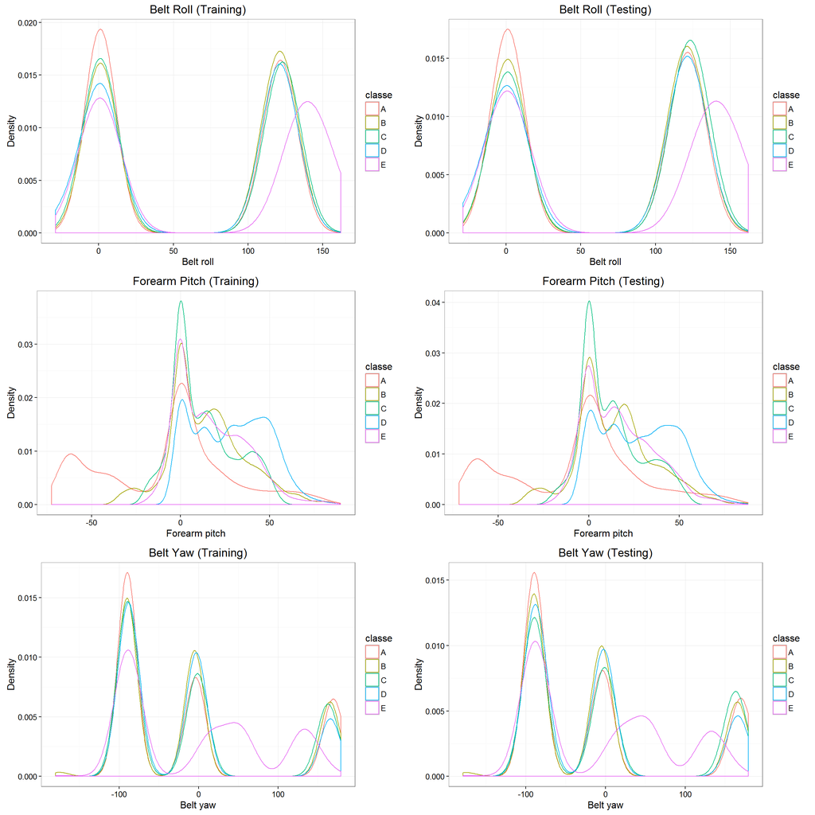

```r
d.plots <- function(predictor, data, title, label) {
    qplot(predictor, colour = classe, data = data, geom = "density") +
        xlab(label) +
        ylab("Density") +
        ggtitle(title) +
        theme_bw()
}

g1 <- d.plots(training$roll_belt, training, "Belt Roll (Training)", "Belt roll")
g2 <- d.plots(testing$roll_belt, testing, "Belt Roll (Testing)", "Belt roll")
g3 <- d.plots(training$pitch_forearm, training, "Forearm Pitch (Training)", "Forearm pitch")
g4 <- d.plots(testing$pitch_forearm, testing, "Forearm Pitch (Testing)", "Forearm pitch")
g5 <- d.plots(training$yaw_belt, training, "Belt Yaw (Training)", "Belt yaw")
g6 <- d.plots(testing$yaw_belt, testing, "Belt Yaw (Testing)", "Belt yaw")

require(gridExtra)
grid.arrange(g1, g2, g3, g4, g5, g6, nrow = 3, ncol = 2)
```

**Figure 2.** Three most important predictors and their distributions by outcome class in the training and testing sets.

These top three predictors indicate that Class E has higher belt roll than the other classes, Class A has lower forearm pitch and Class D has higher forearm pitch than the other classes, and Class E has higher belt yaw.

## Predicting the unlabelled validation set

Finally, the outcome was predicted using the random forests algorithm on the unlabelled data. The results are displayed below.

```r
require(magrittr)

asNumeric <- function(x) as.numeric(as.character(x))
factorsNumeric <- function(d) modifyList(d, lapply(d[, sapply(d, is.factor)],
                                                asNumeric))
validation %>%
    subset(select = -c(X, user_name, raw_timestamp_part_1, raw_timestamp_part_2,
                      cvtd_timestamp, new_window, num_window, problem_id)) %>%
    factorsNumeric -> validation[ , 8:159]
```

```r
# Make predictions on validation set
predictions <- predict(model, validation[,8:159])
# Print predictions
data.frame(problem_id = validation$problem_id, prediction = predictions)
```

```
##    problem_id prediction
## 1           1          B
## 2           2          A
## 3           3          B
## 4           4          A
## 5           5          A
## 6           6          E
## 7           7          D
## 8           8          B
## 9           9          A
## 10         10          A
## 11         11          B
## 12         12          C
## 13         13          B
## 14         14          A
## 15         15          E
## 16         16          E
## 17         17          A
## 18         18          B
## 19         19          B
## 20         20          B
```